# R Notebook

# Loading libraries

```r
library(tidyverse)
library(modelr)
library(car)
library(GGally)
library(relaimpo)
library(janitor)
```

# Reading in data and exploring

```r
avocado_data <- read.csv("data/avocado.csv") %>%
  clean_names()

glimpse(avocado_data)

view(avocado_data)

view(unique(avocado_data$region))
```

I have chosen to build an explanatory model for the average_price.

#Tidying avocado_data

```r
avocado_data_clean <- avocado_data %>%
  dplyr::select(-c(x, date, year)) %>%
  mutate(region = as.character(region)) %>%
  mutate(region = if_else(str_detect(region,
 "Albany|BaltimoreWashington|BuffaloRochester|Boston|Charlotte|Detroit|HarrisburgScranton|HartfordSpringfield|Indianapolis|Jacksonville|Nashville|NewYork|Northeast|NorthernNewEngland|Orlando|Philadelphia|Pittsburgh|RichmondNorfolk|Roanoke|SouthCarolina|Southeast|Syracuse|Tampa|MiamiFtLauderdale|Atlanta"), "East", region)) %>%
  mutate(region = if_else(str_detect(region,
 "Chicago|CincinnatiDayton|DallasFtWorth|Denver|Houston|Columbus|GreatLakes|Louisville|GrandRapids|Midsouth|NewOrleansMobile|Plains|StLouis"), "Midwest", region)) %>%
   mutate(region = if_else(str_detect(region,
 "Boise|California|DallasFtWorth|Denver|Houston|LasVegas|LosAngeles|PhoenixTucson|Portland|RaleighGreensboro|Sacramento|SanDiego|SanFrancisco|Seattle|SouthCentral|Spokane|WestTexNewMexico"), "West", region)) %>%
  mutate(region = as.factor(region))

glimpse(avocado_data_clean)
```

# Checking if TotalUS equates to all the other region categories added together

```r
avocado_data_clean %>%
  filter(region == "TotalUS") %>%
  summarise(sum(total_volume))

avocado_data_clean %>%
  filter(region != "TotalUS") %>%
  summarise(sum(total_volume))

# Doesn't appear to be the case
```

```r
avocado_data %>%
  ggplot(aes(x = region, y = average_price)) +
  geom_boxplot()

#Boxplot shows that region doesn't look like an important factor (not much separation between variable types) so it will be dropped
```

[output not shown]

```r
avocado_data_clean <- avocado_data_clean %>%
  dplyr::select(-region)
```

```r
glimpse(avocado_data_clean)
```

```
Rows: 18,249
Columns: 10
$ average_price <dbl> 1.33, 1.35, 0.93, 1.08, 1.28, 1.26, 0.99, 0.98, 1.02, 1.07, 1.12, 1.28, 1.31, 0.99, 1.33, 1.28, 1…
$ total_volume  <dbl> 64236.62, 54876.98, 118220.22, 78992.15, 51039.60, 55979.78, 83453.76, 109428.33, 99811.42, 74338…
$ x4046         <dbl> 1036.74, 674.28, 794.70, 1132.00, 941.48, 1184.27, 1368.92, 703.75, 1022.15, 842.40, 924.86, 1582…
$ x4225         <dbl> 54454.85, 44638.81, 109149.67, 71976.41, 43838.39, 48067.99, 73672.72, 101815.36, 87315.57, 64757…
$ x4770         <dbl> 48.16, 58.33, 130.50, 72.58, 75.78, 43.61, 93.26, 80.00, 85.34, 113.00, 117.07, 105.32, 101.36, 1…
$ total_bags    <dbl> 8696.87, 9505.56, 8145.35, 5811.16, 6183.95, 6683.91, 8318.86, 6829.22, 11388.36, 8625.92, 8205.6…
$ small_bags    <dbl> 8603.62, 9408.07, 8042.21, 5677.40, 5986.26, 6556.47, 8196.81, 6266.85, 11104.53, 8061.47, 7877.8…
$ large_bags    <dbl> 93.25, 97.49, 103.14, 133.76, 197.69, 127.44, 122.05, 562.37, 283.83, 564.45, 327.80, 257.63, 376…
$ x_large_bags  <dbl> 0.00, 0.00, 0.00, 0.00, 0.00, 0.00, 0.00, 0.00, 0.00, 0.00, 0.00, 0.00, 0.00, 0.00, 0.00, 0.00, 0…
$ type          <fct> conventional, conventional, conventional, conventional, conventional, conventional, conventional,…
```

```r
dim(avocado_data_clean)

avocado_trim <- avocado_data_clean %>%
  drop_na()
dim(avocado_trim)
```

Looking at the distribution for average_price

```r
avocado_trim %>%
  ggplot(aes(average_price))+
  geom_histogram()
```

# Checking for alias variables

```r
alias(average_price ~ ., data = avocado_trim)
```

No alias variables in avocado_data_clean

# Finding correlation between variables and average_price

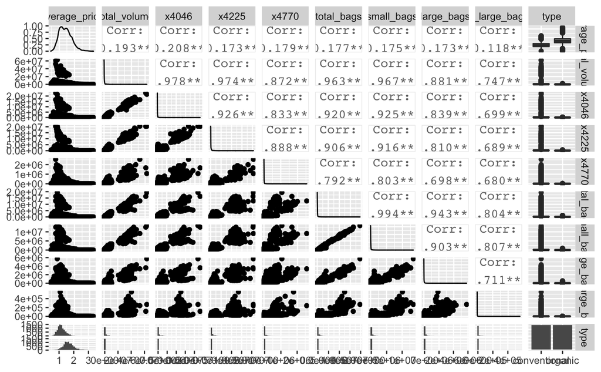

```r
ggpairs(avocado_trim)
```

Few of numeric variables show particularly strong correlation with average_price.

The highest correlation value is x4046 - 0.208 followed by total_volume - 0.193

The boxplot for type and average price shows separation between the two variable types.

#Building model

## 1st predictor

x4046 and average_price model

```r
mod1a <- mod1a <- lm(average_price ~ x4046, data = avocado_trim)
summary(mod1a)
```

Residual standard error: 0.3939 on 18247 degrees of freedom Multiple R-squared: 0.0434

```r
par(mfrow = c(2,2))
plot(mod1a)
```

total_volume and average_price model

```r
mod1b <- mod1b <- lm(average_price ~ total_volume, data = avocado_trim)
summary(mod1b)
```

Residual standard error: 0.3951 on 18247 degrees of freedom Multiple R-squared: 0.03715

Higher RSE and lower r-sq value than mod1a

```r
par(mfrow = c(2,2))
plot(mod1b)
```

I will proceed with x4046

## 2nd Predictor

Adding residuals from mod1a and removing average_price and x4046

```r
avocado_resid <- avocado_trim  %>%
  add_residuals(mod1a) %>%
  dplyr::select(-c(average_price, x4046))
```

```r
ggpairs(avocado_resid)
```

```r
mod2 <- lm(average_price ~ x4046 + type, data = avocado_trim)
summary(mod2)
```

Residual standard error: 0.316 on 18246 degrees of freedom Multiple R-squared: 0.3843

RSE is down from mod1a and r-sq value is greater too indicating a better model

```r
par(mfrow = c(2,2))
plot(mod2)
```

#Adding interaction

```r
mod3 <- lm(average_price ~ x4046 + type + x4046:type, data = avocado_trim)
summary(mod3)
```

```
Call:
lm(formula = average_price ~ x4046 + type + x4046:type, data = avocado_trim)

Residuals:
     Min       1Q   Median       3Q      Max
-1.22604 -0.19907 -0.02641  0.18691  1.58753

Coefficients:
                    Estimate Std. Error t value Pr(>|t|)
(Intercept)        1.171e+00  3.472e-03  337.38   <2e-16 ***
x4046             -2.292e-08  1.891e-09  -12.12   <2e-16 ***
typeorganic        4.951e-01  4.895e-03  101.14   <2e-16 ***
x4046:typeorganic -1.676e-06  1.402e-07  -11.95   <2e-16 ***
---
Signif. codes:  0 ‘***’ 0.001 ‘**’ 0.01 ‘*’ 0.05 ‘.’ 0.1 ‘ ’ 1

Residual standard error: 0.3148 on 18245 degrees of freedom
Multiple R-squared:  0.3891,    Adjusted R-squared:  0.389
F-statistic:  3874 on 3 and 18245 DF,  p-value: < 2.2e-16
```

Residual standard error: 0.3148 on 18245 degrees of freedom Multiple R-squared: 0.3891

RSE is down from mod2 and r-sq value is greater too, indicating better model.

# Testing relative importance

```r
calc.relimp(mod3, type = "lmg", rela = TRUE)
```

[output not shown]